# Assignment 1

Gijs Smeets, group 35

February 2023

## Short introduction to R Markdown

### Figures

You can control the size and placement of figures. For example, you can put two figures (or more) next to each other. Use `par(mfrow=c(n,m))` to create `n` by `m` plots in one picture in R. You can adjust the proportions of figures by using the `fig.width` and `fig.height` chunk options. These are specified in inches, and will be automatically scaled down to fit within the handout margin. Chunk option `fig.align` takes values `left`, `right`, or `center` (to align figures in the output document).

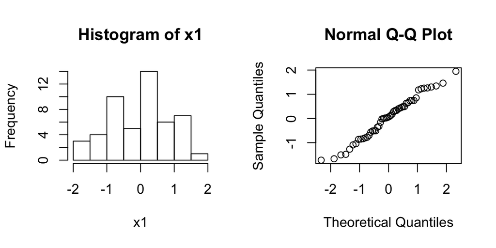

```r
par(mfrow=c(1,2)); x1=rnorm(50); hist(x1); qqnorm(x1)
```

You can arrange for figures to span across the entire page by using the `fig.fullwidth` chunk option.

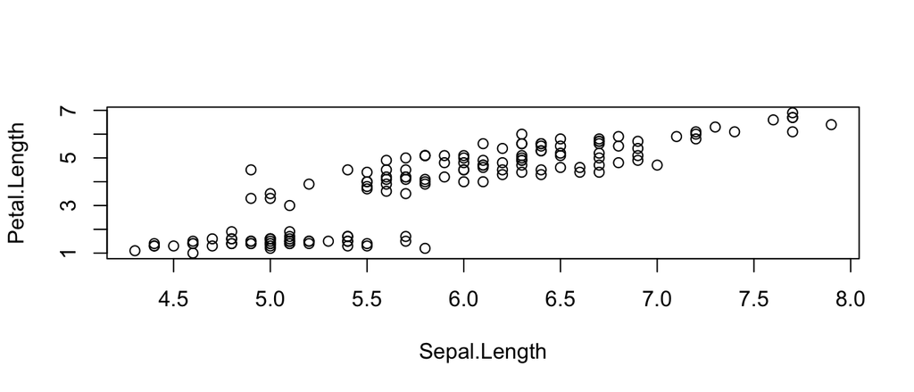

```r
plot(iris$Sepal.Length,iris$Petal.Length,xlab="Sepal.Length",ylab="Petal.Length")
```

### Footnotes

Here is the use of a footnote[^1].

### Images

Want an image? This will do it. To depict an image (say, `my_image.jpg` which should be in your current working directory), use this command

[figure not shown]

caption for my image

### Tables

Want a table? This will create one (note that the separators *do not* have to be aligned).

| Table Header | Second Header |
| --- | --- |
| Table Cell | Cell 2 |
| Cell 3 | Cell 4 |

You can also make table by using knit’s `kable` function:

A knit kable.

|  | mpg | cyl | disp | hp | drat | wt | qsec | vs | am | gear | carb |
| --- | --- | --- | --- | --- | --- | --- | --- | --- | --- | --- | --- |
| Mazda RX4 | 21.0 | 6 | 160 | 110 | 3.90 | 2.620 | 16.46 | 0 | 1 | 4 | 4 |
| Mazda RX4 Wag | 21.0 | 6 | 160 | 110 | 3.90 | 2.875 | 17.02 | 0 | 1 | 4 | 4 |
| Datsun 710 | 22.8 | 4 | 108 | 93 | 3.85 | 2.320 | 18.61 | 1 | 1 | 4 | 1 |
| Hornet 4 Drive | 21.4 | 6 | 258 | 110 | 3.08 | 3.215 | 19.44 | 1 | 0 | 3 | 1 |
| Hornet Sportabout | 18.7 | 8 | 360 | 175 | 3.15 | 3.440 | 17.02 | 0 | 0 | 3 | 2 |

### Block quote

> This will create a block quote, if you want one.

### Verbatim

```
This text is displayed verbatim/preformatted.
```

### Links

Links: http://example.com, [in-text link to Google](http://google.com).

### Itimization, italicized and embolded text

- Single asterisks italicize text *like this*.
- Double asterisks embolden text **like this**.

One more way to italicize and embold: *italic* and **bold**.

## Exercise 1

Below is a template for reporting the exercises from the assignments.

**a)** Here are some consequitive R-commands.

```r
x=rep(c("A","B"),each=5); x
```

```
##  [1] "A" "A" "A" "A" "A" "B" "B" "B" "B" "B"
```

```r
sample(x)
```

```
##  [1] "B" "A" "A" "B" "A" "A" "B" "A" "B" "B"
```

```r
x=rnorm(100)
```

Now the same code chunk but with all the output collapsed into signle block.

```r
x=rep(c("A","B"),each=5); x
##  [1] "A" "A" "A" "A" "A" "B" "B" "B" "B" "B"
sample(x)
##  [1] "A" "A" "A" "B" "A" "B" "B" "B" "A" "B"
x=rnorm(100)
```

**b)** Below we perform a one sample t-test for the artificial data (that we generate ourselves).

```r
mu=0.2
x=rnorm(100,mu,1) # creating artificial data
t.test(x,mean=0)   # t.test(x,alternative=c("two.sided"),conf.level=0.95,mu=10)
```

```
##
##  One Sample t-test
##
## data:  x
## t = 2.5186, df = 99, p-value = 0.01339
## alternative hypothesis: true mean is not equal to 0
## 95 percent confidence interval:
##  0.06423118 0.54124770
## sample estimates:
## mean of x
## 0.3027394
```

**c)** We often do not need to report the whole output of R-commands, only certain values of the output. For example, below we perform a two-sample t-test and report only the (appropriately rounded) values of t-statistics and the p-pavue.

```r
mu=0;nu=0.5
x=rnorm(50,mu,1); y=rnorm(50,nu,1) # creating artificial data
ttest=t.test(x,y)
```

The value of t-statistics in the above evaluation is -2.99 and the p-value is 0.0036.

[^1]: This is a footnote.